# P5

## P5 Convolutioneel neuraal netwerk

Voor deze opdracht ga ik kijken convolutioneel neuraal netwerk trainen om de CIFAR-10 dataset te classificeren. Eerst zet ik een simpele baseline op en vervolgens ga ik hiermee aan de slag om te kijken wat ik allemaal kan toevoegen om mijn netwerk te verbeteren.

```python
import matplotlib.pyplot as plt
import numpy as np
import tensorflow as tf
import pickle
from tensorflow.keras import datasets, layers, models
from keras.preprocessing.image import ImageDataGenerator
```

[output not shown]

Na het importeren van de benodigde packages kunnen we de dataset inladen

```python
Dataset = tf.keras.datasets.cifar10
```

```python
(train_images, train_labels), (test_images, test_labels) = datasets.cifar10.load_data()

train_images, test_images = train_images / 255.0, test_images / 255.0
```

Nu even de data checken of het inladen goed gelukt is en zoals hieronder te zien is de data goed ingeladen.

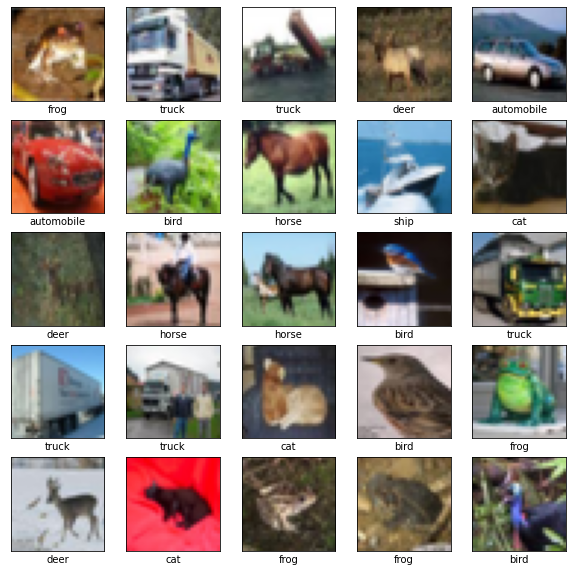

```python
class_names = ['airplane', 'automobile', 'bird', 'cat', 'deer',
               'dog', 'frog', 'horse', 'ship', 'truck']

plt.figure(figsize=(10,10))
for i in range(25):
    plt.subplot(5,5,i+1)
    plt.xticks([])
    plt.yticks([])
    plt.grid(False)
    plt.imshow(train_images[i])
    # The CIFAR labels happen to be arrays,
    # which is why you need the extra index
    plt.xlabel(class_names[train_labels[i][0]])
plt.show()
```

Voor de baseline houden we het model vrij eenvoudig.

```python
model = models.Sequential()
model.add(layers.Conv2D(32, (3, 3), activation='relu', input_shape=(32, 32, 3)))
model.add(layers.MaxPooling2D((2, 2)))
model.add(layers.Conv2D(64, (3, 3), activation='relu'))
model.add(layers.MaxPooling2D((2, 2)))
model.add(layers.Conv2D(64, (3, 3), activation='relu'))

model.add(layers.Flatten())
model.add(layers.Dense(64, activation='relu'))
model.add(layers.Dense(10))
```

Kleine check van het model

```python
model.summary()
```

[output not shown]

Nu we alle data hebben en ons model is opgezet kunnen we beginnen met het trainen van ons model.

```python
model.compile(optimizer='adam',
              loss=tf.keras.losses.SparseCategoricalCrossentropy(from_logits=True),
              metrics=['accuracy'])

history = model.fit(train_images, train_labels, epochs=10,
                    validation_data=(test_images, test_labels))
```

```
313/313 - 1s - loss: 0.9468 - accuracy: 0.6819 - 1s/epoch - 3ms/step
```

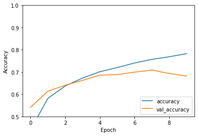

```python
plt.plot(history.history['accuracy'], label='accuracy')
plt.plot(history.history['val_accuracy'], label = 'val_accuracy')
plt.xlabel('Epoch')
plt.ylabel('Accuracy')
plt.ylim([0.5, 1])
plt.legend(loc='lower right')

test_loss, test_acc = model.evaluate(test_images,  test_labels, verbose=2)
```

### Conclusie eerste model

Voor en basale opzet van een model is een 68% accuracy niet eens zo heel slecht. Ook valt er te zien dat het model vanaf Epoch 4 vast loopt.

# Uitbreiden van het model

#### Image augmentation

Na het onderzoeken hoe ik modellen kan verbeteren kwam ik al snel uit bij image augmentation. Wat dit precies inhoudt is dat wij doormiddel van het aanpassen van onze huidige afbeeldingen meerdere geformateerde afbeeldingen maak zodat er meer data is om mee te werken.

Zo kan je het model testen op data welke nog onbekend is voor het model. zo is de waarde van deze accuracy meer waard.

Ik heb hieronder de data augmentation voor de afbeeldingen aangemaakt. Ik heb hier een beetje met de parameters heen en weer geschoven tot ik een volgens mij goed genoeg resultaat kreeg.

```python
datagen = ImageDataGenerator(
    # rotation_range=15,
    horizontal_flip=True,
    width_shift_range=0.15,
    height_shift_range=0.25
    #zoom_range=0.3
    )
datagen.fit(test_images)
```

Nu na het aanpassen van de data laden laad ik het in om te kijken of het formateren gelukt is.

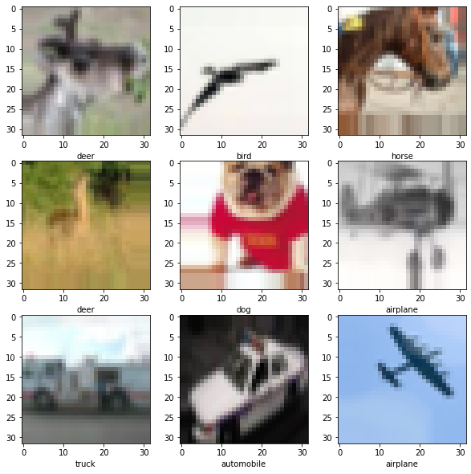

```python
labels = ['airplane', 'automobile', 'bird', 'cat', 'deer',
                'dog', 'frog', 'horse', 'ship', 'truck']
plt.figure(figsize=(10,10))
for X_batch, y_batch in datagen.flow(train_images, train_labels, batch_size=9):
    for i in range(0, 9):
        plt.subplot(330 + 1 + i)
        plt.imshow(X_batch[i])
        plt.xlabel(labels[y_batch[i][0]])
    plt.show()
    break
```

Het nieuwe model is hieronder opgezet, er zijn een aantal dingen toegevoegd aan de baseline.

1. Meerdere layers
2. een kernel regularizer
3. padding
4. een kernel initializer
5. Dropouts
6. en batch normalization

```python
model = models.Sequential()
model.add(layers.Conv2D(32, (5, 5), activation='relu', kernel_initializer='he_uniform', padding='same', kernel_regularizer=tf.keras.regularizers.l2(0.001), input_shape=(32, 32, 3)))
model.add(layers.BatchNormalization())
model.add(layers.Conv2D(32, (5, 5), activation='relu', kernel_initializer='he_uniform', padding='same', kernel_regularizer=tf.keras.regularizers.l2(0.001)))
model.add(layers.MaxPooling2D((2, 2)))
model.add(layers.Dropout(0.2))
model.add(layers.Conv2D(64, (3, 3), activation='relu', kernel_initializer='he_uniform', padding='same', kernel_regularizer=tf.keras.regularizers.l2(0.001)))
model.add(layers.BatchNormalization())
model.add(layers.Conv2D(64, (3, 3), activation='relu', kernel_initializer='he_uniform', padding='same', kernel_regularizer=tf.keras.regularizers.l2(0.001)))
model.add(layers.MaxPooling2D((2, 2)))


model.add(layers.Flatten())
model.add(layers.Dense(256, activation='relu', kernel_initializer='he_uniform', kernel_regularizer=tf.keras.regularizers.l2(0.001)))
model.add(layers.Dense(10, activation='softmax'))
```

Ook hier een kleine check naar het nieuwe model.

```python
model.summary()
```

[output not shown]

```python
test_images_augmented, test_labels_augmented = next(datagen.flow(test_images, test_labels, batch_size=test_images.shape[0], shuffle=False))
```

Nu we het nieuwe model hebben kunnen we deze gaan trainen.

```python
model.compile(
    optimizer='adam',
    loss=tf.keras.losses.SparseCategoricalCrossentropy(),
    metrics=['accuracy'],
    )


history = model.fit(test_images, test_labels, steps_per_epoch=50000//128, epochs=10,
                    validation_data=(test_images, test_labels))
```

En nu het nieuwe model getrained is kunnen we de resultaten tonen!!!

```
313/313 - 7s - loss: 0.9113 - accuracy: 0.8139 - 7s/epoch - 21ms/step
313/313 - 7s - loss: 1.5510 - accuracy: 0.6304 - 7s/epoch - 22ms/step
```

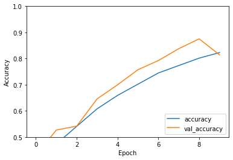

```python
plt.plot(history.history['accuracy'], label='accuracy')
plt.plot(history.history['val_accuracy'], label = 'val_accuracy')
plt.xlabel('Epoch')
plt.ylabel('Accuracy')
plt.ylim([0.5, 1])
plt.legend(loc='lower right')

test_loss, test_acc = model.evaluate(test_images,  test_labels, verbose=2)
test_loss, test_acc = model.evaluate(test_images_augmented,  test_labels_augmented, verbose=2)
```

# Conclussie

## onderzoek en waarnemingen

Verder heb ik erg veel dingen uitgeprobeerd en geleerd alleen jammer genoeg liep ik een beetje tegen performance issues van mijn mac book aan dit limiteerde mij best wel wat.

Echter heb ik toch best veel dingen geprobeerd zoals een schedular toevoegen en grotere netwerken geprobeerd alleen dit leide jammer genoeg tot alleen maar slechtere resultaten. Hierom ben ik weer terug gegaan naar mijn werkende model en heb ik deze verder wat uitgebreidt.